# Week12

Julie_Overgaard

2024-03-22

# Assignment week 12

## Visualize the duration of reign among Danish kings through time (showing the diachronic trend from ca 900 - today on the x axis) with ggplot.

```r
library(tidyverse)
kings <- read_csv("data/Kongerække-Ark1.csv",na="N/A")
getwd()
```

```
## [1] "/Users/juliehojstrupovergaard/Documents/Digitale arkiver og metode/Timen uge 11"
```

```r
kings
```

```
## # A tibble: 55 × 5
##    Navne         Fødselsdato Dødsdato Start_på_regeringstid Slut_på_regeringstid
##    <chr>               <dbl>    <dbl>                 <dbl>                <dbl>
##  1 Gorm den Gam…          NA      958                    NA                  958
##  2 Harald 1. bl…         932      987                   958                  987
##  3 Svend 1. Tve…          NA     1014                   987                 1014
##  4 Harald 2.              NA     1018                  1014                 1018
##  5 Knud 1. den …         995     1035                  1018                 1035
##  6 Hardeknud            1020     1042                  1035                 1042
##  7 Magnus den g…        1024     1047                  1042                 1047
##  8 Svend 2. Est…          NA     1076                  1047                 1074
##  9 Harald 3. Hen          NA     1080                  1074                 1080
## 10 Knud 2. den …          NA     1086                  1080                 1086
## # ℹ 45 more rows
```

```r
view(kings)
names(kings)
```

```
## [1] "Navne"                 "Fødselsdato"           "Dødsdato"
## [4] "Start_på_regeringstid" "Slut_på_regeringstid"
```

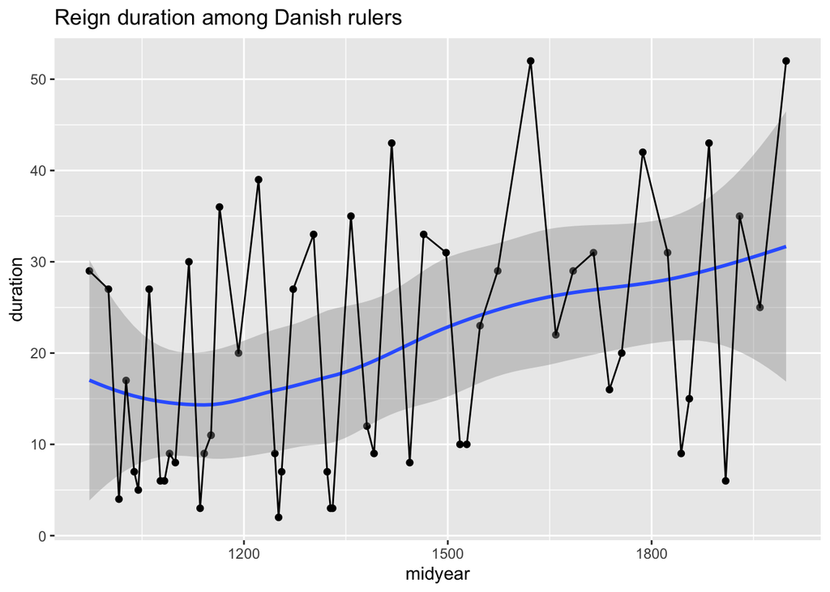

```r
kings %>%
  mutate(duration = Slut_på_regeringstid - Start_på_regeringstid) %>%
  mutate(midyear = Slut_på_regeringstid - duration/2) %>%
  ggplot(aes(x = midyear, y = duration)) +
  geom_point() +
  geom_smooth() +
  geom_line() +
  labs(title = "Reign duration among Danish rulers", x = "midyear", y = "duration")
```

### Historical homicide trends across Western Europe (ggplot practice)

```r
Western_Europe <- read_csv("data1/homicide-rates-across-western-europe.csv", na = "NA")
getwd()
```

```
## [1] "/Users/juliehojstrupovergaard/Documents/Digitale arkiver og metode/Timen uge 11"
```

```r
Western_Europe
```

```
## # A tibble: 206 × 4
##    Entity  Code   Year Homicide rate in Europe over long-term (per 100,000) (h…¹
##    <chr>   <chr> <dbl>                                                     <dbl>
##  1 England ""     1300                                                      23
##  2 England ""     1550                                                       7
##  3 England ""     1625                                                       6
##  4 England ""     1675                                                       4
##  5 England ""     1725                                                       2
##  6 England ""     1775                                                       1
##  7 England ""     1812                                                       2
##  8 England ""     1837                                                       1.7
##  9 England ""     1862                                                       1.6
## 10 England ""     1887                                                       0.8
## # ℹ 196 more rows
## # ℹ abbreviated name:
## #   ¹`Homicide rate in Europe over long-term (per 100,000) (homicides per 100,000 people)`
```

```r
view(Western_Europe)
head(Western_Europe)
```

```
## # A tibble: 6 × 4
##   Entity  Code   Year Homicide rate in Europe over long-term (per 100,000) (ho…¹
##   <chr>   <chr> <dbl>                                                      <dbl>
## 1 England ""     1300                                                         23
## 2 England ""     1550                                                          7
## 3 England ""     1625                                                          6
## 4 England ""     1675                                                          4
## 5 England ""     1725                                                          2
## 6 England ""     1775                                                          1
## # ℹ abbreviated name:
## #   ¹`Homicide rate in Europe over long-term (per 100,000) (homicides per 100,000 people)`
```

##ggplot

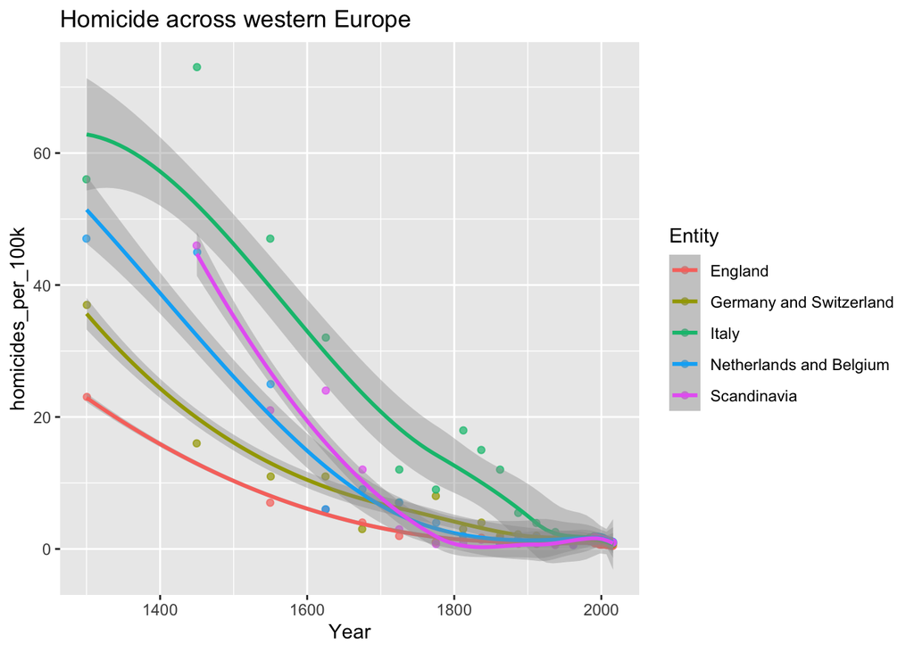

```r
Western_Europe %>%
  ggplot(aes(x = Year, y = `Homicide rate in Europe over long-term (per 100,000) (homicides per 100,000 people)`, color = Entity)) +
  geom_jitter(alpha = 0.7) +
  geom_smooth() +
  labs(title = "Homicide across western Europe", fill = "Country", x = "Year", y = "homicides_per_100k")
```

## Uncouple the homicides of individual countries for easier view

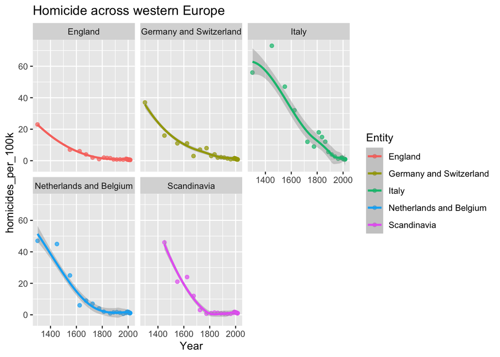

```r
Western_Europe %>%
  ggplot(aes(x = Year, y = `Homicide rate in Europe over long-term (per 100,000) (homicides per 100,000 people)`, color = Entity)) +
  geom_jitter(alpha = 0.7) +
  geom_smooth() +
  labs(title = "Homicide across western Europe", fill = "Country", x = "Year", y = "homicides_per_100k") +
  facet_wrap(~ Entity)
```

## Compare the trends in homicide with the pattern of reign duration among Danish rulers through time

- While the homicide rate has been dropping, the duration of Danish kings reign has been increasing

## Final Task

-1. Plot: In the facetted plot above, move the legend from the current position on the side to below the facets, and label it “Country” instead of “Entity”.

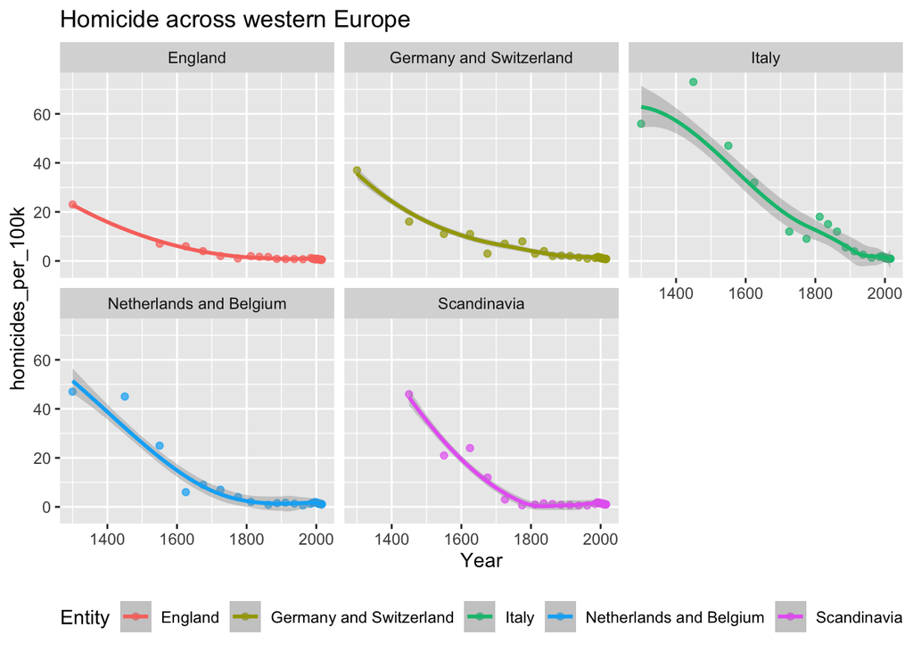

```r
Western_Europe %>%
  ggplot(aes(x = Year, y = `Homicide rate in Europe over long-term (per 100,000) (homicides per 100,000 people)`, color = Entity)) +
  geom_jitter(alpha = 0.7) +
  geom_smooth() +
  labs(title = "Homicide across western Europe", fill = "Country", x = "Year", y = "homicides_per_100k") +
  facet_wrap(~ Entity) +
  theme(legend.position = "bottom") +
  scale_fill_discrete(name = "Country")
```

## In <250 words articulate your answer on the basis of the data visualisations to the following question: are we more civilized today?

-Whether we are more or less civilized today than in the past is a very complex question. Based on the minimal data available in this assignment, it is not possible to draw conclusions on all the complex parts of the question. The available material accounts for two phenomena; the reign of kings in Denmark and the number of murders in Europe. Therefore, the question will be answered based on these two factors. The reign of kings has been on the rise, and there are many factors behind this. As it is not common for Danish monarchs to abdicate, we must see the end of their reign as a result of their death, meaning that monarchs have started to live longer. This can be explained mainly by improved health. But another trend among Danish rulers has disappeared, there hasn’t been a regicide in Denmark since 1286. A society without regicide and with an improved view on health can be said to be more civilized than before. The number of murders in Europe has been decreasing. This doesn’t say anything about the health of societies, but can be compared to the number of royal murders in Denmark, which has also been decreasing. The fact that the number of murders is decreasing indicates that societies have changed, one explanation for the decrease in murders could be that societies have a better legal system, with better punishment for breaking the law. Another explanation could be improved living standards, which could reduce crime. These two explanations for changes that could have occurred in societies both suggest that societies have become more civilized. In other words, both parts of the assignment suggest that we are more civilized today.